# 第10课 回归分析之二 答案

顶刊研习社

Li Zongzhang

2023-10-29

```r
library(boot)
library(tidyverse)
library(survival)
library(survminer)
library(gt)
library(gtsummary)
```

# 1 习题1

数据文件：poisson_sim.csv

下载链接：[数据文件下载](https://pan.baidu.com/s/13Kv8qLdUs-J0l8FRK5qCvg?pwd=1234)

运行以下代码，创建数据框df

```r
# 导入数据文件poisson_sim.csv，该文件放置在项目所在的同一路径下。
# 若数据文件poisson_sim.csv没有放在与项目同一路径，需要在read.csv()中指定数据文件的路径。


df <- read.csv("poisson_sim.csv")

df <- within(df, {
  prog <- factor(prog,
                 levels=1:3,
                 labels=c("General",
                          "Academic",
                          "Vocational"))
  id <- factor(id)
})

head(df)
```

```
   id num_awards       prog math
1  45          0 Vocational   41
2 108          0    General   41
3  15          0 Vocational   44
4  67          0 Vocational   42
5 153          0 Vocational   40
6  51          0    General   42
```

num_awards: The number of awards earned by students at one high school. prog: the type of program in which the student was enrolled (e.g., vocational, general or academic) math: the score on their final exam in math.

1.1 绘制df中num_awards的图像，考察其分布特征。

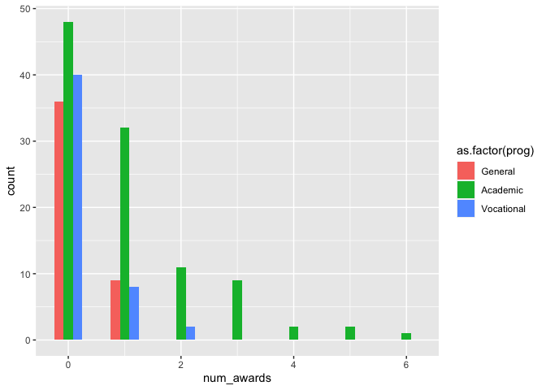

```r
ggplot(df, aes(num_awards,
               group = prog,
               fill = as.factor(prog))) +
  geom_histogram(binwidth=.5,
                 position="dodge")
```

1.2 构建关于num_awards的poisson回归模型，用表格报告其结果。

```r
poisson_m1 <- glm(num_awards ~ prog + math,
    family="poisson", df)

poisson_m1 %>%
  tbl_regression()
```

| **Characteristic** | **log(IRR)**<sup>1</sup> | **95% CI**<sup>1</sup> | **p-value** |
| --- | --- | --- | --- |
| prog |  |  |  |
| General | — | — |  |
| Academic | 1.1 | 0.44, 1.9 | 0.002 |
| Vocational | 0.37 | -0.49, 1.3 | 0.4 |
| math | 0.07 | 0.05, 0.09 | <0.001 |

<sup>1</sup> IRR = Incidence Rate Ratio, CI = Confidence Interval

```r
poisson_m1 %>%
  tbl_regression(exponentiate = TRUE,
                 estimate_fun = ~ style_number(.x, digits = 3),
                 pvalue_fun = ~ style_pvalue(.x, digits = 3)
  ) %>%
  add_global_p() %>%
  add_glance_table(
    include = c(nobs,
                logLik,
                AIC,
                BIC)
  )
```

| **Characteristic** | **IRR**<sup>1</sup> | **95% CI**<sup>1</sup> | **p-value** |
| --- | --- | --- | --- |
| prog |  |  | <0.001 |
| General | — | — |  |
| Academic | 2.956 | 1.545, 6.397 |  |
| Vocational | 1.447 | 0.613, 3.547 |  |
| math | 1.073 | 1.051, 1.095 | <0.001 |
| No. Obs. | 200 |  |  |
| Log-likelihood | -183 |  |  |
| AIC | 374 |  |  |
| BIC | 387 |  |  |

<sup>1</sup> IRR = Incidence Rate Ratio, CI = Confidence Interval

IRR得含义：

在其他条件保持不变的情况下, 平均而言, academic组的number of awards是基准类general组的2.956倍

在其他条件保持不变的情况下,平均而言, Vocational组的number of awards是基准类general组的1.447倍.

在其他条件保持不变的情况下, math提高1分，平均而言，number of awards将是原来的1.073倍.

1.3 绘制poisson回归中系数的图像。

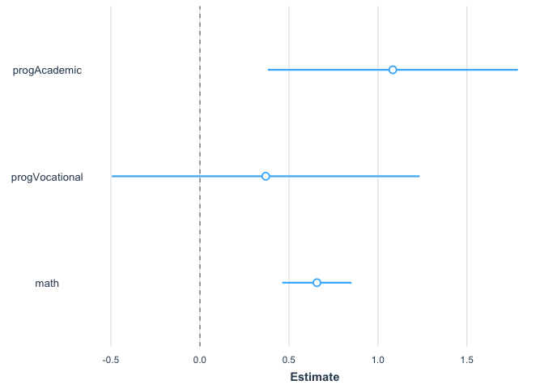

```r
# install.packages("jtools")
library(jtools)
# install.packages("broom.mixed")
library(broom.mixed)
jtools::plot_summs(poisson_m1, scale = TRUE, exp = FALSE)
```

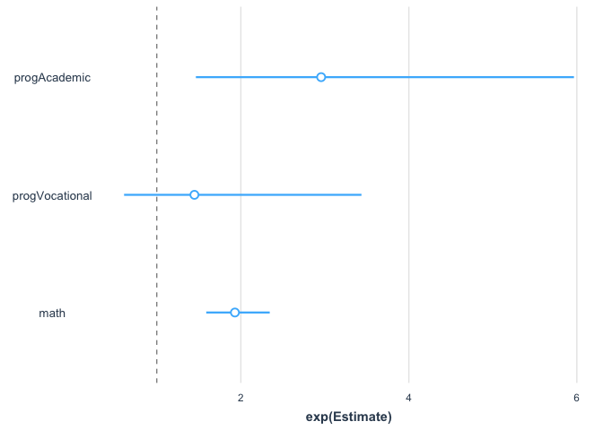

```r
jtools::plot_summs(poisson_m1, scale = TRUE, exp = TRUE)
```

1.4 计算poisson回归模型中的被解释变量对各个解释变量在样本均值点的边际效应。

```r
mfx::poissonmfx(num_awards ~ prog + math , data = df)
```

```
Call:
mfx::poissonmfx(formula = num_awards ~ prog + math, data = df)

Marginal Effects:
                   dF/dx Std. Err.      z     P>|z|
progAcademic   0.4535889 0.1510959 3.0020  0.002682 **
progVocational 0.1671110 0.2192606 0.7622  0.445966
math           0.0287373 0.0043571 6.5955 4.237e-11 ***
---
Signif. codes:  0 '***' 0.001 '**' 0.01 '*' 0.05 '.' 0.1 ' ' 1

dF/dx is for discrete change for the following variables:

[1] "progAcademic"   "progVocational"
```

在样本均值点，academic组的number of awards比基准类general组多0.45个。

在样本均值点，vocational组的number of awards比基准类general组多0.17个。

在样本均值点，math增加1分，number of awards多0.03个。

1.5 对1.2中的poisson回归进行诊断，检验其显著性。

```r
poisson_m1 <- glm(num_awards ~ prog + math ,
                  data = df, family=poisson)
poisson_null <- glm(num_awards ~ 1,
                    data = df, family=poisson)
anova(poisson_null, poisson_m1, test = "Chisq")
```

```
Analysis of Deviance Table

Model 1: num_awards ~ 1
Model 2: num_awards ~ prog + math
  Resid. Df Resid. Dev Df Deviance  Pr(>Chi)
1       199     287.67
2       196     189.45  3   98.223 < 2.2e-16 ***
---
Signif. codes:  0 '***' 0.001 '**' 0.01 '*' 0.05 '.' 0.1 ' ' 1
```

poisson回归方程整体显著。

# 2 习题2

```r
library(dplyr)
library(forcats)
library(finalfit)
```

数据文件：{epiDisplay} Marryage数据集

```r
library(epiDisplay)
data(Marryage)
library(survival)
```

2.1 查看Marryage数据集的帮助说明。

```r
?Marryage
```

2.2 用codebook()查看Marryage数据集中变量编码的含义。

```r
codebook(Marryage)
```

```
id   :
 obs. mean   median  s.d.   min.   max.
 27   14     14      7.937  1      27

 ==================
sex      :
       Frequency Percent
male           9    33.3
female        18    66.7

 ==================
birthyr      :   year of birth
 obs. mean     median  s.d.   min.   max.
 27   1962.148 1963    6.106  1952   1972

 ==================
educ     :   level of education
          Frequency Percent
bach-            13    48.1
>bachelor        14    51.9

 ==================
marital      :   marital status
        Frequency Percent
Single         11    40.7
Married        16    59.3

 ==================
maryr    :   year of marriage
 obs. mean     median  s.d.   min.   max.
 16   1987.562 1988    5.176  1979   1995

 ==================
endyr    :   year of analysis
 obs. mean   median  s.d.   min.   max.
 27   1997   1997    0      1997   1997

 ==================
```

2.3 计算Marryage数据集中个案的年龄，以及结婚时的年龄，并将这两个变量追加到Marryage数据集中，命名为age和age.marry。

```r
Marryage$age <- Marryage$endyr - Marryage$birthyr
Marryage$age.marr <-  Marryage$maryr - Marryage$birthyr
```

2.4 在Marryage数据集追加变量married, 当个案已婚时，married为TRUE，否则为FALSE。在Marryage数据集追加变量time, 当个案已婚时，time为个案结婚时的年龄，否则为个案的年龄.

```r
Marryage$married <- Marryage$marital == "Married"
Marryage$time <- ifelse(Marryage$married, Marryage$age.marr, Marryage$age)
```

2.5 将Marryage数据集中的sex, educ, married, time变量提取出来，命名为df数据集。

```r
df <- Marryage %>%
  dplyr::select(sex, educ, married, time)
```

2.6 用tbl_uvregression报告所有的一元回归的结果。解读Cox回归的估计结果。

```r
df %>%
  gtsummary::tbl_uvregression(
    method = coxph,
    y = Surv(time, married),
    exponentiate = TRUE
  )
```

| **Characteristic** | **N** | **HR**<sup>1</sup> | **95% CI**<sup>1</sup> | **p-value** |
| --- | --- | --- | --- | --- |
| sex | 27 |  |  |  |
| male |  | — | — |  |
| female |  | 0.84 | 0.30, 2.35 | 0.7 |
| educ | 27 |  |  |  |
| bach- |  | — | — |  |
| >bachelor |  | 1.09 | 0.40, 2.96 | 0.9 |

<sup>1</sup> HR = Hazard Ratio, CI = Confidence Interval

2.7 利用df数据集构建Cox回归，解释变量为sex和educ, 解读Cox回归的估计结果。

```r
res.cox <- df %>%
  coxph(Surv(time, married) ~ sex + educ, data = .)

summary(res.cox)
```

```
Call:
coxph(formula = Surv(time, married) ~ sex + educ, data = .)

  n= 27, number of events= 16

                  coef exp(coef) se(coef)      z Pr(>|z|)
sexfemale     -0.18543   0.83074  0.65416 -0.283    0.777
educ>bachelor -0.02539   0.97493  0.64050 -0.040    0.968

              exp(coef) exp(-coef) lower .95 upper .95
sexfemale        0.8307      1.204    0.2305     2.994
educ>bachelor    0.9749      1.026    0.2778     3.421

Concordance= 0.543  (se = 0.073 )
Likelihood ratio test= 0.11  on 2 df,   p=0.9
Wald test            = 0.11  on 2 df,   p=0.9
Score (logrank) test = 0.11  on 2 df,   p=0.9
```

The coefficient of “sexfemale” is negative and non-significant. The hazard ratio, exp(coef), is 0.83, suggesting an overall reduction of 17% hazard rate of females compared to males. The 95% confidence interval for the hazard ratio is (0.23, 2.994), which includes 1.Therefore, the hazard ratio is not statistically significant.

2.6 绘制基线生存函数曲线。

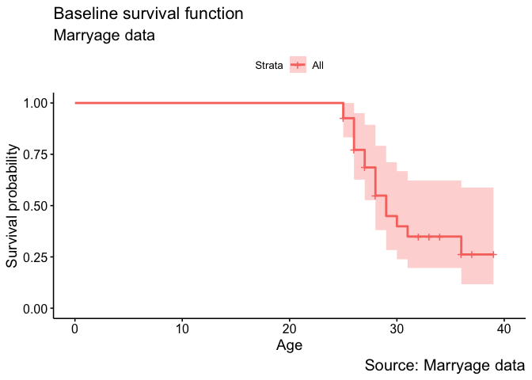

```r
library(survminer)
survival::survfit(Surv(time, married) ~ 1, df) %>%
  survminer::ggsurvplot() +
  labs(title = "Baseline survival function",
       subtitle = "Marryage data",
       caption = "Source: Marryage data",
       x = "Age",
       y = "Survival probability")
```

2.7 计算25岁、30岁、35岁、39岁时婚姻存续概率。

```r
summary(survival::survfit(Surv(time, married) ~ 1,
                          data = df),
        times = c(25, 30, 35, 39))
```

```
Call: survfit(formula = Surv(time, married) ~ 1, data = df)

 time n.risk n.event survival std.err lower 95% CI upper 95% CI
   25     27       2    0.926  0.0504        0.832        1.000
   30      9      12    0.399  0.1048        0.238        0.668
   35      4       1    0.349  0.1029        0.196        0.622
   39      1       1    0.262  0.1080        0.117        0.588
```

2.8 计算婚姻存续者的中位数年龄。

```r
survfit(Surv(time, married) ~ 1, data = df)
```

```
Call: survfit(formula = Surv(time, married) ~ 1, data = df)

      n events median 0.95LCL 0.95UCL
[1,] 27     16     29      28      NA
```

2.9 分性别绘制婚姻存续生存曲线 Survival curves

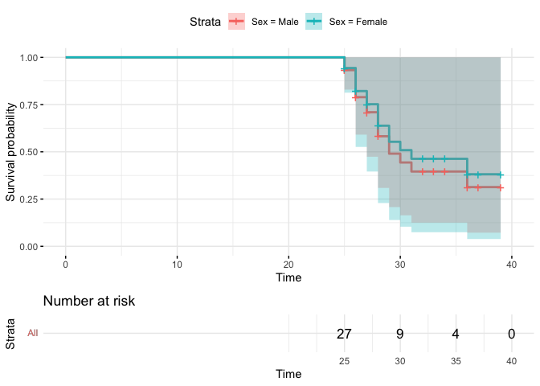

```r
sex_df <- data.frame(sex = c(1, 2),
                     educ = 1)

fit <- survfit(res.cox, newdata = sex_df)

ggsurvplot(fit, conf.int = TRUE,
           data = lung,
           risk.table = TRUE,
           legend.labs=c("Sex = Male", "Sex = Female"),
           ggtheme = theme_minimal())
```